# Chapter 4: Producer Theory & the Islamic Firm

## 4.1 Introduction

The Islamic firm operates under distinct constraints that fundamentally differ from conventional economic theory:

1. **Riba Prohibition**: No interest-based debt financing. The firm cannot borrow capital at a fixed interest rate.
2. **Reliance on Equity-like Contracts**: Profit-loss sharing (PLS) arrangements such as mudarabah and musharakah.
3. **Gharar Constraint**: Excessive uncertainty in contracts is prohibited, restricting contract space.
4. **Halal Requirement**: All inputs and outputs must be halal (permissible under Islamic law).

These constraints create a fundamentally different production and financing structure, with implications for firm behavior, investment patterns, and market outcomes.

## 4.2 The Islamic Production Set

### Standard Production Set

In conventional microeconomic theory, the production set is defined as:

$$Y \subseteq \mathbb{R}^L$$

where $L$ is the number of goods, and $y \in Y$ represents a feasible production plan with $y_\ell < 0$ for inputs and $y_\ell > 0$ for outputs.

### Islamic Modification

The Islamic production set imposes an additional constraint: the firm can only produce outputs that are halal and use inputs that are halal.

**Definition 4.1** (Islamic Production Set): Let $\mathcal{H}^c$ denote the set of haram (forbidden) goods. The Islamic production set is:

$$Y^I = \left\{y \in Y : y_\ell^+ = 0 \text{ for all } \ell \in \mathcal{H}^c\right\}$$

where $y_\ell^+ = \max(y_\ell, 0)$ is the output of good $\ell$. This means the firm produces zero quantity of any haram good.

### Implications

- The Islamic production set is a strict subset of the conventional set: $Y^I \subsetneq Y$
- This constraint may render some otherwise profitable production plans infeasible
- The firm faces a trade-off between profit maximization and Islamic compliance
- Classification of halal vs haram goods is determined by religious jurisprudence (fiqh)

## 4.3 Financing Constraints — The Riba Prohibition

### The Problem with Interest-Based Financing

In conventional finance, a firm can borrow capital $K$ at an interest rate $r$. The cost of debt financing is simply:

$$C_{\text{debt}} = r \cdot K$$

Riba (usury/interest) is explicitly prohibited in Islamic law. The Qur'an states: "Allah will destroy usury but will give increase for deeds of charity" (Qur'an 2:276).

Therefore, the Islamic firm cannot use conventional debt financing. Instead, it must rely on profit-loss sharing contracts.

### Mudarabah Contract

**Definition 4.2** (Mudarabah Contract):

A mudarabah is a partnership contract between:

- **Rabb-ul-mal** (capital provider): Contributes capital $K$
- **Mudarib** (entrepreneur): Provides labor and expertise

The profits are divided by a pre-agreed ratio $(\theta, 1-\theta)$ where:

- Capital provider receives share $\theta$ of profits: $\theta \pi(K)$
- Entrepreneur receives share $1-\theta$ of profits: $(1-\theta)\pi(K)$

**Losses** are borne by the capital provider (up to the capital contributed). The entrepreneur's loss is limited to foregone labor compensation.

### Musharakah Contract

**Definition 4.3** (Musharakah Contract):

Musharakah is a full partnership contract where:

- Both parties contribute capital: $K_1 + K_2 = K_{\text{total}}$
- Both parties participate in management
- Profits and losses are shared proportionally to capital contribution (or by agreed ratio):
  - Party 1 receives share $\alpha$ of profits/losses
  - Party 2 receives share $1-\alpha$ of profits/losses

### Cost of Capital under PLS

Under a mudarabah contract, the firm's expected cost of capital depends on the expected profit distribution:

$$C_{\text{PLS}} = E[\theta \cdot \pi(K)]$$

The cost of capital is **endogenous** — it depends on the profit function, not a fixed contractual rate.

Key insight: The capital provider's expected return rises with firm profitability. This creates **alignment of interests** between capital provider and entrepreneur.

## 4.4 Profit Maximization under Islamic Constraints

### The Firm's Optimization Problem

Under a mudarabah contract, the entrepreneur (mudarib) solves:

$$\max_{y \in Y^I, K} (1-\theta)\pi(y, K) \quad \text{s.t.} \quad \pi(y, K) = p \cdot y - w \cdot n - \text{other costs}$$

The entrepreneur maximizes their share of profits, which is $(1-\theta)$ times the total profit.

### Proposition 4.1: Pro-cyclical Investment

**Proposition 4.1**: Under mudarabah financing, the firm exhibits pro-cyclical investment behavior:

1. When expected returns are **high** (economic boom), the entrepreneur willingly invests more capital because their share $(1-\theta)\pi(K)$ increases sharply
2. When expected returns are **low** (recession), the entrepreneur has little incentive to seek additional capital because profits are low

In contrast, under fixed-rate debt financing, the firm's willingness to borrow is relatively insensitive to profit expectations (holding leverage constant).

**Implication**: Islamic financing may amplify business cycles. However, the capital provider's willingness to fund also moves pro-cyclically, creating potential for credit crunches.

**Proof Sketch**:

- Under debt: Firm is insolvent if $\pi(K) < r \cdot K$
- Under musharakah: Both parties share losses, reducing the threshold for financial distress
- As losses are absorbed by both parties, neither party bears the full downside alone
- This creates a more stable capital structure

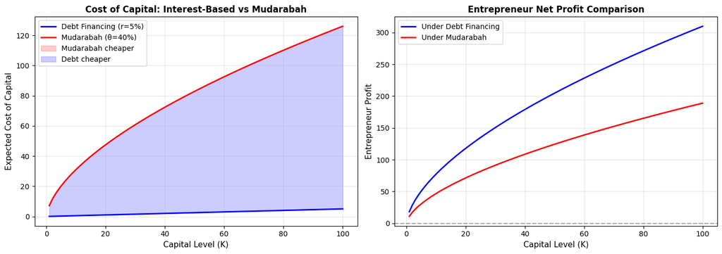

```
Figure 4.1 saved: Financing costs comparison
```

```python
# Simulation: Financing Costs Comparison
import numpy as np
import matplotlib.pyplot as plt
from scipy.stats import lognorm

# Parameters
K = np.linspace(1, 100, 100)  # Capital levels
r = 0.05  # Fixed interest rate (5%)
theta = 0.4  # Capital provider's share in mudarabah

# Profit function: pi(K) = A * K^alpha - fixed costs
A = 20  # Productivity parameter
alpha = 0.6  # Diminishing returns
fixed_costs = 2

def profit_function(K, A=20, alpha=0.6, fc=2):
    return A * (K ** alpha) - fc

pi_K = np.array([profit_function(k) for k in K])

# Cost under debt financing
cost_debt = r * K

# Cost under mudarabah (capital provider expects: theta * pi(K))
cost_mudarabah = theta * pi_K

# Entrepreneur's net profit under mudarabah
entrepreneur_profit = (1 - theta) * pi_K

# Net profit under debt financing (after interest payments)
net_profit_debt = pi_K - cost_debt

# Plot 1: Cost of Capital Comparison
fig, (ax1, ax2) = plt.subplots(1, 2, figsize=(14, 5))

# Left panel: Cost of Capital
ax1.plot(K, cost_debt, 'b-', linewidth=2, label='Debt Financing (r=5%)')
ax1.plot(K, cost_mudarabah, 'r-', linewidth=2, label='Mudarabah (θ=40%)')
ax1.fill_between(K, cost_debt, cost_mudarabah, where=(cost_debt > cost_mudarabah),
                  alpha=0.2, color='red', label='Mudarabah cheaper')
ax1.fill_between(K, cost_debt, cost_mudarabah, where=(cost_debt <= cost_mudarabah),
                  alpha=0.2, color='blue', label='Debt cheaper')
ax1.set_xlabel('Capital Level (K)', fontsize=11)
ax1.set_ylabel('Expected Cost of Capital', fontsize=11)
ax1.set_title('Cost of Capital: Interest-Based vs Mudarabah', fontsize=12, fontweight='bold')
ax1.legend(loc='best')
ax1.grid(True, alpha=0.3)

# Right panel: Entrepreneur's Net Return
ax2.plot(K, net_profit_debt, 'b-', linewidth=2, label='Under Debt Financing')
ax2.plot(K, entrepreneur_profit, 'r-', linewidth=2, label='Under Mudarabah')
ax2.axhline(y=0, color='k', linestyle='--', alpha=0.3)
ax2.set_xlabel('Capital Level (K)', fontsize=11)
ax2.set_ylabel('Entrepreneur Profit', fontsize=11)
ax2.set_title('Entrepreneur Net Profit Comparison', fontsize=12, fontweight='bold')
ax2.legend(loc='best')
ax2.grid(True, alpha=0.3)

plt.tight_layout()
plt.savefig('fig4_1_financing_costs.png',
            dpi=300, bbox_inches='tight')
plt.show()

print("Figure 4.1 saved: Financing costs comparison")
```

[output not shown]

[figure not shown]

```
Figure 4.2 saved: Bankruptcy simulation
Average bankruptcy rate - Debt: 0.00%
Average bankruptcy rate - Musharakah: 0.00%
```

```python
# Simulation: Bankruptcy Risk under Debt vs Musharakah
import numpy as np
import matplotlib.pyplot as plt

np.random.seed(42)

# Monte Carlo Simulation
n_firms = 1000
n_periods = 50
time_periods = np.arange(n_periods)

# Firm parameters
K_firm = 50  # Capital per firm
base_productivity = 20
shock_volatility = 0.15
debt_rate = 0.05
musharakah_share = 0.5  # Each party bears 50% of loss

# Initialize results
bankruptcy_debt = np.zeros(n_periods)
bankruptcy_musharakah = np.zeros(n_periods)
avg_leverage_debt = np.zeros(n_periods)
avg_leverage_musharakah = np.zeros(n_periods)

for t in range(n_periods):
    # Generate productivity shocks
    shocks = np.random.normal(1, shock_volatility, n_firms)

    # Profits: shocks affect productivity
    profits = base_productivity * shocks * (K_firm ** 0.6) - 2

    # Debt financing scenario: bankruptcy if profit < debt payment
    debt_obligations = debt_rate * K_firm
    insolvent_debt = (profits < debt_obligations).sum()
    bankruptcy_debt[t] = insolvent_debt / n_firms
    avg_leverage_debt[t] = debt_rate

    # Musharakah scenario: bankruptcy if loss exceeds partner's capital
    # Both partners share losses proportionally
    # Insolvency is when accumulated losses exceed own capital contribution
    insolvent_musharakah = np.maximum(0, -profits) > (musharakah_share * K_firm)
    bankruptcy_musharakah[t] = insolvent_musharakah.sum() / n_firms
    avg_leverage_musharakah[t] = musharakah_share

# Plotting
fig, (ax1, ax2) = plt.subplots(2, 1, figsize=(12, 9))

# Top panel: Bankruptcy rates over time
ax1.plot(time_periods, bankruptcy_debt * 100, 'b-', linewidth=2.5, label='Debt Financing (5% interest)')
ax1.plot(time_periods, bankruptcy_musharakah * 100, 'g-', linewidth=2.5, label='Musharakah (50-50 sharing)')
ax1.fill_between(time_periods, bankruptcy_debt * 100, alpha=0.2, color='blue')
ax1.fill_between(time_periods, bankruptcy_musharakah * 100, alpha=0.2, color='green')
ax1.set_ylabel('Bankruptcy Rate (%)', fontsize=11)
ax1.set_title('Firm Insolvency Rates: Debt vs Musharakah Financing', fontsize=12, fontweight='bold')
ax1.legend(loc='best', fontsize=10)
ax1.grid(True, alpha=0.3)
ax1.set_ylim(0, max(bankruptcy_debt.max() * 100, bankruptcy_musharakah.max() * 100) * 1.1)

# Bottom panel: Cumulative insolvencies
cum_insolvency_debt = np.cumsum(bankruptcy_debt)
cum_insolvency_musharakah = np.cumsum(bankruptcy_musharakah)

ax2.plot(time_periods, cum_insolvency_debt * 100, 'b-', linewidth=2.5, label='Debt Financing')
ax2.plot(time_periods, cum_insolvency_musharakah * 100, 'g-', linewidth=2.5, label='Musharakah')
ax2.fill_between(time_periods, cum_insolvency_debt * 100, alpha=0.2, color='blue')
ax2.fill_between(time_periods, cum_insolvency_musharakah * 100, alpha=0.2, color='green')
ax2.set_xlabel('Time Period', fontsize=11)
ax2.set_ylabel('Cumulative Insolvency Rate (%)', fontsize=11)
ax2.set_title('Cumulative Insolvency: Risk Accumulation Over Time', fontsize=12, fontweight='bold')
ax2.legend(loc='best', fontsize=10)
ax2.grid(True, alpha=0.3)

plt.tight_layout()
plt.savefig('fig4_2_bankruptcy_simulation.png',
            dpi=300, bbox_inches='tight')
plt.show()

print(f"Figure 4.2 saved: Bankruptcy simulation")
print(f"Average bankruptcy rate - Debt: {bankruptcy_debt.mean()*100:.2f}%")
print(f"Average bankruptcy rate - Musharakah: {bankruptcy_musharakah.mean()*100:.2f}%")
```

## 4.5 The Gharar Constraint on Contracts

### Definition of Gharar

Gharar (غرر) literally means "deception" or "hazard" in Arabic. In Islamic legal tradition, it refers to excessive uncertainty or ambiguity in a contract.

**Definition 4.4** (Gharar-free Contract):

A contract is gharar-free if:

1. The distributions of payoffs are **known** to both parties
2. The contract terms are **unambiguous** and clearly specified
3. Neither party can exploit information asymmetries
4. The subject matter of the contract is clearly defined

**Examples of Gharar**:

- Selling fish in the sea (fish cannot be delivered as specified)
- Buying an item of unknown quality/quantity
- Derivatives with undefined payoff distributions
- Insurance products without clear terms

### Implications for Contract Space

The gharar constraint significantly **restricts the contract space** available to firms:

1. **No pure speculation**: Contracts must have an underlying purpose, not pure gambling
2. **No excessive leverage**: Derivatives that amplify risk exposure beyond measurable limits are forbidden
3. **Equity participation permitted**: Risk-sharing through known proportions is gharar-free
4. **Forward sales restricted**: Salam (forward sale) is permitted only if goods are fully specified

### Proposition 4.3: Gharar Constraint and Contract Space

**Proposition 4.3**: The gharar constraint rules out certain derivative contracts but permits risk-sharing through equity participation.

**Formal Statement**: Let $\mathcal{C}$ be the space of all contracts in a conventional economy, and $\mathcal{C}^I$ be the space of gharar-free contracts. Then:

- $\mathcal{C}^I \subsetneq \mathcal{C}$ (Islamic contracts are a strict subset)
- Equity contracts (mudarabah, musharakah) $\in \mathcal{C}^I$
- Pure speculation contracts $\notin \mathcal{C}^I$
- Certain derivatives $\notin \mathcal{C}^I$ due to unknown payoff distributions

## 4.6 Supply Function of the Islamic Firm

### Derivation of Supply Function

The firm's supply function maps output prices and input prices to the optimal production quantity.

For a competitive firm under mudarabah financing:

$$y^S(p, w, \theta, K) = \arg\max_y (1-\theta)[p \cdot y - w \cdot n(y)]$$

First-order condition: $$p = w \cdot \frac{\partial n}{\partial y}(y^S)$$

### Key Differences from Conventional Supply

The Islamic firm's supply function depends on:

1. **Output price** $p$ (standard)
2. **Input prices** $w$ (standard)
3. **Profit-sharing ratio** $\theta$ (unique to Islamic financing)
4. **Capital availability** $K$ (affected by capital provider's participation)
5. **Expected profit distribution** (not just actual prices)

**Key Insight**: When the capital provider is pessimistic about future profits, they may be unwilling to supply capital at any sharing ratio, effectively constraining the firm's output.

### Supply under Uncertainty vs Certainty

- Under **certainty**: $y^S = y^S(p, w)$ depends only on prices
- Under **uncertainty**: $y^S = y^S(p, w, E[\pi], \text{Var}[\pi])$ also depends on profit expectations

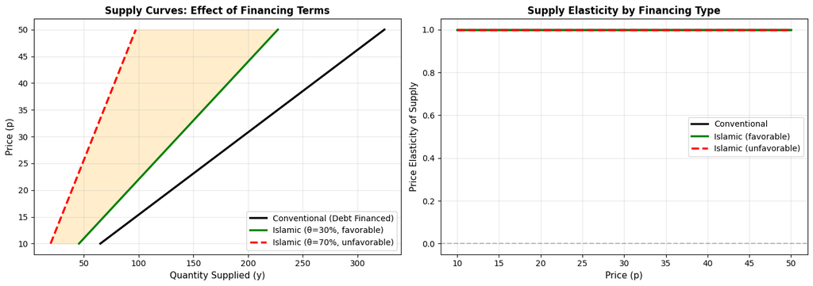

```
Figure 4.3 saved: Supply curves comparison
```

```python
# Supply Curves: Standard vs Islamic Firm
import numpy as np
import matplotlib.pyplot as plt

# Parameters
p = np.linspace(10, 50, 100)  # Price levels
w = 5  # Wage (input price)
theta_high = 0.3  # Capital provider's share - favorable terms
theta_low = 0.7  # Capital provider's share - unfavorable terms

# Production function: y = A * (K/w)^alpha
# Assuming optimal labor choice given capital
K = 50  # Capital level
A = 30
alpha = 0.7

# Supply function: y^S(p) relates price to optimal output
# From profit max: p = MC(y), and MC depends on production efficiency

def supply_conventional(p, K, w, alpha=0.7, A=30):
    """Conventional firm supply: p = MC(y)"""
    # MC = w / (alpha * A * K^alpha)
    mc_const = w / (alpha * A * (K ** alpha))
    return p / mc_const * 0.1  # Normalized supply response

def supply_islamic_favorable(p, K, w, theta=0.3, alpha=0.7, A=30):
    """Islamic firm supply with favorable financing (low theta)"""
    # Entrepreneur keeps (1-theta) of profits, so same MC but scaled by (1-theta)
    base_supply = supply_conventional(p, K, w, alpha, A)
    return base_supply * (1 - theta)  # Higher willingness to supply with better terms

def supply_islamic_unfavorable(p, K, w, theta=0.7, alpha=0.7, A=30):
    """Islamic firm supply with unfavorable financing (high theta)"""
    base_supply = supply_conventional(p, K, w, alpha, A)
    return base_supply * (1 - theta)  # Lower willingness to supply with worse terms

# Calculate supplies
y_conventional = np.array([supply_conventional(price, K, w) for price in p])
y_islamic_favorable = np.array([supply_islamic_favorable(price, K, w, theta_high) for price in p])
y_islamic_unfavorable = np.array([supply_islamic_unfavorable(price, K, w, theta_low) for price in p])

# Plot 1: Supply curves by financing type
fig, (ax1, ax2) = plt.subplots(1, 2, figsize=(14, 5))

# Left panel: Supply curves
ax1.plot(y_conventional, p, 'k-', linewidth=2.5, label='Conventional (Debt Financed)')
ax1.plot(y_islamic_favorable, p, 'g-', linewidth=2.5, label='Islamic (θ=30%, favorable)')
ax1.plot(y_islamic_unfavorable, p, 'r--', linewidth=2.5, label='Islamic (θ=70%, unfavorable)')
ax1.fill_betweenx(p, y_islamic_unfavorable, y_islamic_favorable, alpha=0.2, color='orange')
ax1.set_xlabel('Quantity Supplied (y)', fontsize=11)
ax1.set_ylabel('Price (p)', fontsize=11)
ax1.set_title('Supply Curves: Effect of Financing Terms', fontsize=12, fontweight='bold')
ax1.legend(loc='best')
ax1.grid(True, alpha=0.3)

# Right panel: Supply elasticity
elasticity_conventional = np.gradient(y_conventional, p) * p / y_conventional
elasticity_islamic_fav = np.gradient(y_islamic_favorable, p) * p / y_islamic_favorable
elasticity_islamic_unfav = np.gradient(y_islamic_unfavorable, p) * p / y_islamic_unfavorable

ax2.plot(p, elasticity_conventional, 'k-', linewidth=2.5, label='Conventional')
ax2.plot(p, elasticity_islamic_fav, 'g-', linewidth=2.5, label='Islamic (favorable)')
ax2.plot(p, elasticity_islamic_unfav, 'r--', linewidth=2.5, label='Islamic (unfavorable)')
ax2.axhline(y=0, color='gray', linestyle='--', alpha=0.5)
ax2.set_xlabel('Price (p)', fontsize=11)
ax2.set_ylabel('Price Elasticity of Supply', fontsize=11)
ax2.set_title('Supply Elasticity by Financing Type', fontsize=12, fontweight='bold')
ax2.legend(loc='best')
ax2.grid(True, alpha=0.3)

plt.tight_layout()
plt.savefig('fig4_3_supply_curves.png',
            dpi=300, bbox_inches='tight')
plt.show()

print("Figure 4.3 saved: Supply curves comparison")
```

## 4.7 Summary and Key Takeaways

### Comparison: Conventional vs Islamic Firm

| Characteristic | Conventional Firm | Islamic Firm |
| --- | --- | --- |
| **Financing Method** | Debt (interest-based) | Equity-like (profit-loss sharing) |
| **Cost of Capital** | Fixed interest rate $r$ | Endogenous: $\theta \cdot E[\pi]$ |
| **Production Set** | $Y \subseteq \mathbb{R}^L$ | $Y^I \subsetneq Y$ (halal restriction) |
| **Bankruptcy Risk** | Decreases with profits | Shared with capital provider |
| **Investment Behavior** | Relatively stable | Pro-cyclical (depends on profit expectations) |
| **Contract Space** | Includes derivatives | Gharar-free contracts only |
| **Supply Response** | $y^S(p, w)$ | $y^S(p, w, \theta, E[\pi])$ |
| **Risk Sharing** | Concentrated on entrepreneur | Distributed across parties |

### References

- Al-Ghazali. *Ihya' Ulum ad-Din* (Revival of the Religious Sciences). Islamic classical text on economic ethics.
- Ibn Khaldun. *Muqaddimah* (Introduction to Universal History). Foundational work on economic theory.
- Khan, M. A. (1997). "Islamic Economics and Finance." *Islamic Studies*, 36(4), 357-382.
- Mirakhor, A. & Kabbara, N. (2020). "Epistemology and Finance in Islam." *Journal of Islamic Accounting and Business Research*, 11(1), 1-20.
- Siddiqi, M. N. (2006). *Islamic Banking and Finance in Theory and Practice*. Islamic Economics Research Centre.
- Webber, C. & Wildavsky, A. (1986). *A History of Taxation and Expenditure in the Western World*. Simon and Schuster.